# Finite State Markov Chains

Author

David Evans

Published

March 30, 2026

# 1 Introduction

Many economic phenomena are inherently random and evolve over time. Stock prices fluctuate, economies move between expansions and recessions, and individual workers transition between employment and unemployment. A powerful and widely used tool for modeling these kinds of stochastic dynamics is the **finite state Markov chain**.

A Markov chain describes a random variable that takes on one of a finite number of values, where the probability of transitioning from one value to another depends only on the current state—not on the history of how you got there. This “memoryless” property makes Markov chains both tractable and remarkably useful. They appear throughout economics: in macroeconomic models of business cycles, in labor economics models of job search, in finance models of credit ratings, and in industrial organization models of firm entry and exit.

Before diving into Markov chains, we first need to understand the simpler building block they are constructed from: discrete random variables. In these notes we will:

1. Define **discrete random variables** and show how to simulate them in Julia.
2. Introduce **finite state Markov chains** and the transition matrix $P$.
3. Build a simulation function and apply it to a **business cycle** example.
4. Compute **expected values** and **conditional expectations**, culminating in the key result that the vector of conditional expectations is simply the matrix product $P\bar X$.
5. **Verify** our theoretical formulas using Monte Carlo simulation.
6. **Estimate** the transition matrix from data using **maximum likelihood**, both in closed form and numerically with `Optim.jl`.
7. Compute **multi-step transition probabilities** and show that $P^k$ converges as $k \to \infty$.
8. Find **stationary distributions** as eigenvectors and verify them by simulation.
9. State the **Ergodic Theorem** and connect time averages to ensemble averages.
10. Analyze **mixing time** and the role of eigenvalues in convergence speed.

```julia
using Distributions
using LinearAlgebra
using Plots
```

# 2 Discrete Random Variables

## 2.1 Definition

A **discrete random variable** is a random variable that can take on only a finite number of values. It is completely described by two objects:

1. A vector of possible **values** (sometimes called the state space or support):

$$\bar x = \left(\begin{matrix}\bar x_1\\\bar x_2\\ \vdots\\ \bar x _n\end{matrix}\right)$$

2. A vector of **probabilities**:

$$p = \left(\begin{matrix}p_1\\p_2\\ \vdots\\ p _n\end{matrix}\right)$$

Here $p_i$ represents the probability that the random variable $x$ takes the value $\bar x_i$. For this to be a valid probability distribution, we require that all probabilities are non-negative ($p_i \geq 0$ for all $i$) and that they sum to one:

$$\sum_{i=1}^n p_i = 1$$

## 2.2 Example: A Coin Toss

We have all experienced discrete random variables in our lives. Consider a bet on a coin toss: I bet you $1 that the coin will come up heads. We can describe the random variable $w$ representing your winnings by a vector of outcomes and a vector of probabilities:

$$\bar w = \left(\begin{matrix}-1\\1\end{matrix}\right)
\quad\text{and}\quad
p = \left(\begin{matrix}0.5\\0.5\end{matrix}\right)$$

The first outcome represents the coin coming up heads and you losing a dollar, while the second outcome represents the coin coming up tails and you winning a dollar.

If I were cheating and using a loaded coin, the probability vector might look like:

$$p = \left(\begin{matrix}0.8\\0.2\end{matrix}\right)$$

representing an 80% probability of the coin coming up heads (and you losing).

## 2.3 Representing Discrete Random Variables in Julia

Julia’s `Distributions` package provides the `Categorical` distribution, which is exactly what we need. A `Categorical` distribution takes a vector of probabilities and returns random indices (1, 2, …, $n$) according to those probabilities:

```julia
cointoss = Categorical([0.5, 0.5])   # Fair coin: 50/50 chance of 1 or 2
```

```
Distributions.Categorical{Float64, Vector{Float64}}(support=Base.OneTo(2), p=[0.5, 0.5])
```

We can draw a single random outcome using `rand`:

```julia
rand(cointoss)       # Returns either 1 or 2
```

```
1
```

Or simulate multiple draws at once:

```julia
rand(cointoss, 5)    # Simulates 5 random coin tosses
```

```
5-element Vector{Int64}:
 1
 1
 1
 1
 1
```

Note that `rand` returns **indices** (1 or 2), not the actual values (-1 or 1). To translate these indices into meaningful values, we use a vector of values and index into it:

```julia
wbar = [-1., 1.]
w = wbar[rand(cointoss)]    # Single toss: maps index to value
```

```
-1.0
```

For multiple tosses, we can separate the two steps to see the mapping clearly. First draw the state indices, then look up the corresponding values:

```julia
tosses   = rand(cointoss, 10)    # 10 random state indices (1s and 2s)
winnings = wbar[tosses]          # Map each index to its value (-1 or 1)
hcat(tosses, winnings)           # Display side by side
```

```
10×2 Matrix{Float64}:
 1.0  -1.0
 1.0  -1.0
 1.0  -1.0
 1.0  -1.0
 2.0   1.0
 2.0   1.0
 1.0  -1.0
 2.0   1.0
 2.0   1.0
 1.0  -1.0
```

Each `1` in the left column (state index) maps to `-1.0` in the right column (a loss), and each `2` maps to `1.0` (a win).

The same approach works for a loaded coin. We simply change the probability vector:

```julia
loadedcoin = Categorical([0.8, 0.2])
w = wbar[rand(loadedcoin, 10)]
```

```
10-element Vector{Float64}:
 -1.0
 -1.0
  1.0
 -1.0
 -1.0
 -1.0
 -1.0
 -1.0
 -1.0
 -1.0
```

With the loaded coin, you should see many more $-1$s (losses) than $1$s (wins), reflecting the 80/20 probability split.

# 3 Finite State Markov Chains

## 3.1 Definition and the Transition Matrix

A **Markov chain** extends the idea of a discrete random variable by allowing the probability distribution to change over time, depending on the current state. Formally, let $x_t$ be a random variable at time $t$. A finite state Markov chain is characterized by two objects:

1. A vector of possible **values** $\bar x = (\bar x_1, \bar x_2, \ldots, \bar x_n)'$, just as before.
2. A **transition matrix** of probabilities:

$$P = \left(\begin{matrix}P_{1,1}&P_{1,2}&\cdots&P_{1,n}\\ P_{2,1}&P_{2,2}&\cdots&P_{2,n}\\ \vdots&\vdots&\ddots&\vdots\\ P_{n,1}&P_{n,2}&\cdots&P_{n,n}\end{matrix}\right)$$

The entry $P_{i,j}$ gives the probability that $x_t = \bar x_j$ **conditional on** $x_{t-1} = \bar x_i$. In other words, if we are currently in state $i$, then $P_{i,j}$ tells us the probability of moving to state $j$ in the next period. We often use $s_t$ to denote the index associated with $x_t$: if $x_t = \bar x_i$ then $s_t = i$.

**ImportantProperties of the Transition Matrix**

The transition matrix $P$ must satisfy two conditions:

- All entries are non-negative: $P_{i,j} \geq 0$ for all $i, j$.
- Each **row** sums to one: $\sum_{j=1}^n P_{i,j} = 1$ for all $i$.

Row $i$ of $P$ gives the complete conditional probability distribution of the next state, given that the current state is $i$.

The defining property of a Markov chain is that the transition probabilities depend only on the **current** state, not on the entire history of past states. This is sometimes called the **Markov property** or “memorylessness.” Mathematically: $\Pr(x_t = \bar x_j \mid x_{t-1}, x_{t-2}, \ldots) = \Pr(x_t = \bar x_j \mid x_{t-1}) = P_{s_{t-1}, j}$.

## 3.2 Why Markov Chains? Modeling Persistence

Why would we want to use a Markov chain rather than a simple discrete random variable? The key reason is **persistence**. Many economic variables exhibit serial correlation: when the economy is in a recession, it is more likely to remain in a recession next period than to suddenly jump to a boom. When a worker is unemployed, they are more likely to still be unemployed next month than someone who is currently employed.

A simple discrete random variable with fixed probabilities cannot capture this kind of dependence. But a Markov chain can: by choosing the transition matrix $P$ appropriately, we can make certain transitions more likely than others, building in the persistence we observe in the data.

## 3.3 Business Cycle Example

Let us model output growth as a two-state Markov chain. The economy is either in an **expansion** (output growing at 3%) or a **recession** (output declining at 1%):

```julia
# ḡ is typed as g\bar then tab
ḡ = [0.03, -0.01]    # State 1 = expansion (3%), State 2 = recession (-1%)
```

```
2-element Vector{Float64}:
  0.03
 -0.01
```

The transition matrix captures the persistence of each regime:

```julia
P = [0.9 0.1;
     0.3 0.7]
```

```
2×2 Matrix{Float64}:
 0.9  0.1
 0.3  0.7
```

How do we read this matrix? The first row says that if we are currently in an expansion, there is a 90% chance we remain in an expansion next period and a 10% chance we transition to a recession. The second row says that if we are in a recession, there is a 70% chance we stay in a recession and a 30% chance we recover to an expansion. Both regimes are persistent, but expansions are more persistent than recessions.

## 3.4 Reading the Transition Matrix in Julia

We can extract specific probabilities from the transition matrix using standard indexing:

```julia
P[1, 2]    # Probability of transitioning from boom (state 1) to recession (state 2)
```

```
0.1
```

To get the entire conditional distribution for next period, given that we are currently in a boom, we extract the first row:

```julia
P[1, :]    # Full conditional distribution given current state is boom
```

```
2-element Vector{Float64}:
 0.9
 0.1
```

We can use this row to draw a random value of output next period:

```julia
pboom = Categorical(P[1, :])   # Create distribution from row 1 of P
ḡ[rand(pboom)]                 # Draw a state and look up its value
```

```
0.03
```

# 4 Simulating Markov Chains

## 4.1 The `drawDiscrete` Function

The pattern of creating a `Categorical` distribution and mapping the drawn index to a value comes up repeatedly, so let us wrap it in a reusable function:

```julia
"""
    drawDiscrete(p, X̄)

Draws a discrete random variable with probability vector `p` over values `X̄`.

# Arguments
- `p`: a probability vector (must sum to 1)
- `X̄`: a vector of values corresponding to each state

# Returns
- `(s, X)`: a tuple where `s` is the drawn state index and `X = X̄[s]` is the corresponding value
"""
function drawDiscrete(p, X̄)
    dist = Categorical(p)         # Create the distribution from p
    s = rand(dist)                # Draw a random state index
    X = X̄[s]                     # Look up the value for that state
    return s, X                   # Return both the index and value
end
```

```
Main.Notebook.drawDiscrete
```

This function takes a probability vector `p` and a value vector `X̄`, draws a random state index from the categorical distribution defined by `p`, maps it to the corresponding value, and returns both the index and the value as a tuple.

Let us verify it works with our coin toss examples:

```julia
drawDiscrete([0.5, 0.5], [-1, 1])    # Fair coin
```

```
(1, -1)
```

```julia
drawDiscrete([0.8, 0.2], [-1, 1])    # Loaded coin
```

```
(1, -1)
```

## 4.2 The `simulateMarkov` Function

Since the simulation pattern—pre-allocate arrays, set the initial state, loop forward drawing from the appropriate row of $P$—will be used repeatedly, let us wrap it in a reusable function:

```julia
"""
    simulateMarkov(P, X̄, T; s₁=1)

Simulate a Markov chain for `T` periods.

# Arguments
- `P`: an `n × n` transition matrix
- `X̄`: a vector of values corresponding to each state
- `T`: number of periods to simulate
- `s₁`: initial state index (default: 1)

# Returns
- `(s, X)`: a tuple where `s` is the vector of state indices and `X` is the vector of corresponding values
"""
function simulateMarkov(P, X̄, T; s₁=1)
    X = zeros(T)                          # Pre-allocate values
    s = zeros(Int, T)                     # Pre-allocate state indices
    s[1] = s₁
    X[1] = X̄[s₁]
    for t in 2:T
        s[t], X[t] = drawDiscrete(P[s[t-1], :], X̄)
    end
    return s, X
end
```

```
Main.Notebook.simulateMarkov
```

At each time step, the function extracts row $s_{t-1}$ from the transition matrix $P$ to get the conditional probability vector for the next state, then passes it to `drawDiscrete`. The result is a pair of vectors: `s` containing the state indices (1 or 2 in our example) and `X` containing the corresponding values (growth rates).

**TipPre-allocation**

Notice that the function pre-allocates the arrays `X` and `s` with `zeros` before the loop, rather than growing them with `push!`. This is much more efficient because Julia can allocate a single contiguous block of memory up front. For numerical simulations, always pre-allocate when you know the size of the output.

## 4.3 Simulating a Markov Chain

With `simulateMarkov` in hand, running a simulation is a one-liner:

```julia
s, g = simulateMarkov(P, ḡ, 100)
```

```
([1, 1, 1, 1, 1, 1, 2, 2, 1, 1  …  1, 1, 1, 1, 1, 1, 1, 1, 1, 1], [0.03, 0.03, 0.03, 0.03, 0.03, 0.03, -0.01, -0.01, 0.03, 0.03  …  0.03, 0.03, 0.03, 0.03, 0.03, 0.03, 0.03, 0.03, 0.03, 0.03])
```

This returns the state sequence `s` (a vector of 1s and 2s) and the corresponding growth rates `g`.

## 4.4 Plotting the Simulation

We can visualize the simulated path of output growth:

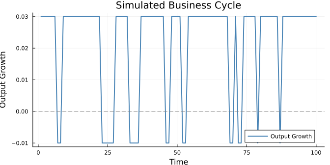

```julia
plot(g, linewidth=2, color=:steelblue, label="Output Growth",
     title="Simulated Business Cycle", size=(700, 350))
hline!([0.0], color=:gray, linestyle=:dash, label="")
xlabel!("Time")
ylabel!("Output Growth")
```

The plot shows the economy alternating between expansion and recession regimes. The dashed line at zero separates positive and negative growth. You can see the persistence at work: the economy tends to stay in each regime for several consecutive periods before transitioning. The expansions (at 3%) tend to last longer than the recessions (at -1%), which is consistent with the transition matrix—the probability of staying in an expansion (0.9) is higher than the probability of staying in a recession (0.7).

## 4.5 Animating the Markov Chain

An animation can help build intuition for how the Markov chain evolves over time. Using the `@animate` macro from `Plots.jl`, we create a GIF that shows the growth path being drawn period by period, with the current state highlighted in green (expansion) or red (recession):

```
[ Info: Saved animation to /var/folders/ms/mjkz2xp96zgblq028jcm5y0r0000gr/T/jl_AtYZMD6nGj.gif
```

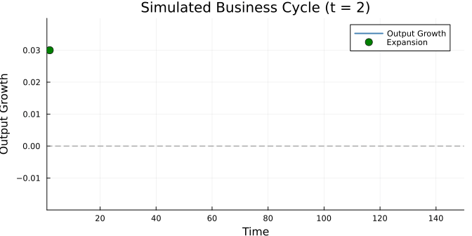

Watch how the economy tends to stay in each regime for stretches before transitioning. The green dots (expansions) tend to cluster together, as do the red dots (recessions)—this is persistence in action.

# 5 Expectations

## 5.1 Expected Value of a Discrete Random Variable

The **expected value** (or mean) of a discrete random variable is the probability-weighted average of all possible values:

$$\mathbb{E}[X] = p_1 \bar X_1 + p_2 \bar X_2 + \ldots + p_n \bar X_n = \sum_{j=1}^n p_j \bar X_j$$

This formula has a natural interpretation: each possible value $\bar X_j$ is weighted by how likely it is to occur ($p_j$), and we sum up all these weighted values. The expected value tells us the long-run average outcome if we were to repeat the random experiment many times.

Notice that the expected value formula is exactly a **dot product** between the probability vector $p$ and the value vector $\bar X$. In Julia, we can compute it directly using the `dot` function from `LinearAlgebra`:

```julia
# Fair coin toss
p = [0.5, 0.5]
w̄ = [-1., 1.]
Ew = dot(p, w̄)   # Expected winnings
```

```
0.0
```

For a fair coin, the expected winnings are zero—which makes intuitive sense, since you are equally likely to win or lose a dollar.

```julia
# Loaded coin toss (80% heads)
p = [0.8, 0.2]
Ew = dot(p, w̄)   # Expected winnings
```

```
-0.6000000000000001
```

With the loaded coin, the expected winnings are $-0.6$: on average, you lose 60 cents per toss. This is the “house edge” when playing against a cheater.

We can verify that `dot` is doing the same thing as the manual calculation:

```julia
p[1]*w̄[1] + p[2]*w̄[2]
```

```
-0.6000000000000001
```

## 5.2 Monte Carlo Verification

One of the most powerful ideas in computational statistics is the **Monte Carlo method**: if you want to know the expected value of a random variable, simply simulate it many times and take the average. By the law of large numbers, the sample average converges to the true expected value as the number of draws $N \to \infty$.

Let us verify our expected value formula using this approach:

```julia
N = 100000                          # Number of draws
w_simulations = zeros(N)            # Pre-allocate results

for i in 1:N                        # Simulate N coin tosses
    s, w = drawDiscrete(p, w̄)      # Toss coin, get winnings
    w_simulations[i] = w            # Store the result
end
mean(w_simulations)                 # Sample average ≈ true expectation
```

```
-0.60514
```

The simulated average should be very close to $-0.6$, confirming our formula. The small discrepancy is due to sampling variability, which shrinks as $N$ increases.

**TipMonte Carlo Method**

The Monte Carlo method is invaluable in economics. Many quantities of interest—expected utilities, option prices, welfare effects of policy changes—are difficult or impossible to compute analytically. But if you can simulate the underlying random process, you can always estimate expectations through averaging. The key requirement is a sufficiently large number of draws $N$.

# 6 Conditional Expectations

## 6.1 Conditional Expectations for Markov Chains

For finite state Markov chains, we are often interested in **conditional expectations**: the expected value of the random variable next period, given information about the current state:

$$\mathbb{E}[X_{t+1} | X_t = \bar X_i]$$

Since the conditional distribution of $X_{t+1}$ given $X_t = \bar X_i$ is determined by row $i$ of the transition matrix $P$, we have:

$$\mathbb{E}[X_{t+1} | X_t = \bar X_i] = \sum_{j=1}^n P_{i,j} \bar X_j$$

This is again a dot product—this time between row $i$ of $P$ and the value vector $\bar X$. We can compute the conditional expectations for our business cycle example:

```julia
# Expected growth rate conditional on currently being in a boom
dot(P[1, :], ḡ)
```

```
0.026
```

```julia
# Expected growth rate conditional on currently being in a recession
dot(P[2, :], ḡ)
```

```
0.0019999999999999996
```

Conditional on being in a boom, expected output growth next period is about 2.6%—close to 3% because there is a high probability of remaining in the expansion. Conditional on being in a recession, expected growth is about 0.2%—slightly positive because there is a 30% chance of transitioning to an expansion.

## 6.2 Conditional Expectations as a Matrix Product

Each conditional expectation is a dot product of $\bar X$ with a row of $P$:

$$\mathbb{E}[X_{t+1} | X_t = \bar X_i] = P_{i,\cdot} \cdot \bar X$$

If we stack all $n$ conditional expectations into a vector, something elegant happens. Each entry is a dot product of $\bar X$ with a different row of $P$, and by definition, stacking all these row-wise dot products is exactly **matrix multiplication**:

$$\left(\begin{matrix}\mathbb{E}[X_{t+1}|X_t = \bar X_1]\\\mathbb{E}[X_{t+1}|X_t = \bar X_2]\\\vdots\\\mathbb{E}[X_{t+1}|X_t = \bar X_n]\end{matrix}\right) = \left(\begin{matrix} P_{1,\cdot}\cdot \bar X \\ P_{2,\cdot}\cdot \bar X \\ \vdots \\ P_{n,\cdot}\cdot \bar X\end{matrix}\right) = P\bar X$$

**ImportantKey Result**

The vector of all conditional expectations equals $P\bar X$—a single matrix multiplication. This is one of the most important computational results for working with Markov chains, and it generalizes: the $k$-step-ahead conditional expectations are given by $P^k \bar X$.

In Julia:

```julia
P * ḡ
```

```
2-element Vector{Float64}:
 0.026
 0.0019999999999999996
```

This matches the individual dot products we computed above, confirming that matrix multiplication is doing exactly what we expect.